# Homework 3

###### Between tree representations tree_rep_tuned, between paa representation sl=5 will be selected

```r
# change selected raw_series and selected representations to long format and store it in a list
raw_series = dcast(reps[,c(1,2,3,4)], id ~ time, value.var = "value")
tree_rep_tuned = dcast(reps[,c(1,2,3,6)], id ~ time, value.var = "tree_rep_tuned")
paa_rep_sl_5 = dcast(reps[,c(1,2,3,7)], id ~ time, value.var = "paa_rep_sl=5")
train_representation_list = list(raw_series, tree_rep_tuned, paa_rep_sl_5)
```

```r
distance(dataset = dataset, reps = train_representation_list, rep_names = c("raw", "tree_rep_tuned", "paa_rep_sl=5"), dist_names = c("euc", "dtw", "lcss", "erp"),  type = type)
```

[output not shown]

```r
dist_files = list.files(pattern = paste0("hw3_TRAIN_", dataset))
dist_files
```

1. 'hw3_TRAIN_Earthquakes_dtw_paa_rep_sl=5_dist.csv'

2. 'hw3_TRAIN_Earthquakes_dtw_raw_dist.csv'

3. 'hw3_TRAIN_Earthquakes_dtw_tree_rep_tuned_dist.csv'

4. 'hw3_TRAIN_Earthquakes_erp_paa_rep_sl=5_dist.csv'

5. 'hw3_TRAIN_Earthquakes_erp_raw_dist.csv'

6. 'hw3_TRAIN_Earthquakes_erp_tree_rep_tuned_dist.csv'

7. 'hw3_TRAIN_Earthquakes_euc_paa_rep_sl=5_dist.csv'

8. 'hw3_TRAIN_Earthquakes_euc_raw_dist.csv'

9. 'hw3_TRAIN_Earthquakes_euc_tree_rep_tuned_dist.csv'

10. 'hw3_TRAIN_Earthquakes_lcss_paa_rep_sl=5_dist.csv'

11. 'hw3_TRAIN_Earthquakes_lcss_raw_dist.csv'

12. 'hw3_TRAIN_Earthquakes_lcss_tree_rep_tuned_dist.csv'

```r
require(TunePareto)

k_levels = c(1, 3, 5)
set.seed(2021)
# 5 repeats of stratified 10-fold cross-validation
nof_rep = 5
n_fold = 10

result = vector('list',length(dist_files)*nof_rep*n_fold*length(k_levels))

# create test indices to be used in cross-validation
train_classes = train_data$class
cv_indices = generateCVRuns(train_classes, ntimes = nof_rep, nfold = n_fold, leaveOneOut = FALSE, stratified = TRUE)

iter=1
# loop to calculate best k value for nearest neighbour with 10-fold-cross-validation, returns accuracy of each run in each fold
for(m in 1:length(dist_files)){
    dist_mat = as.matrix(fread(dist_files[m], header=FALSE))

    for(i in 1:nof_rep){
        this_fold = cv_indices[[i]]

        for(j in 1:n_fold){
            test_indices = this_fold[[j]]

            for(k in 1:length(k_levels)){
                current_k = k_levels[k]
                current_fold = nn_classify(dist_mat, train_classes, test_indices, k = current_k)
                accuracy = sum(train_classes[test_indices]==current_fold$prediction$predicted)/length(test_indices)
                distance_representation_name =  gsub("hw3_TRAIN_Earthquakes_", "", dist_files[m])
                tmp = data.table(representation = gsub("hw3_TRAIN_Earthquakes_", "", dist_files[m]), distance_measure = gsub("hw3_TRAIN_Earthquakes_", "", dist_files[m]), repid = i, foldid = j, k = current_k, acc = accuracy)
                result[[iter]] = tmp
                iter=iter+1

            }

        }

    }

}

overall_results = rbindlist(result)
summary = overall_results[,list(avg_accuracy = mean(acc), sdev_accuracy=sd(acc)), by=list(distance_measure, k)]
summary[order(-avg_accuracy)]
```

| distance_measure | k | avg_accuracy | sdev_accuracy |
| --- | --- | --- | --- |
| lcss_raw_dist.csv | 5 | 0.8198674242 | 0.016610758 |
| lcss_paa_rep_sl=5_dist.csv | 3 | 0.8192234848 | 0.020691641 |
| dtw_paa_rep_sl=5_dist.csv | 5 | 0.8142424242 | 0.024947853 |
| erp_paa_rep_sl=5_dist.csv | 5 | 0.8136174242 | 0.025473661 |
| euc_paa_rep_sl=5_dist.csv | 5 | 0.8087121212 | 0.026010639 |
| lcss_paa_rep_sl=5_dist.csv | 5 | 0.8043371212 | 0.029663287 |
| lcss_raw_dist.csv | 3 | 0.8043371212 | 0.030862479 |
| dtw_raw_dist.csv | 5 | 0.8012500000 | 0.026508000 |
| erp_raw_dist.csv | 5 | 0.7981060606 | 0.036351193 |
| euc_paa_rep_sl=5_dist.csv | 3 | 0.7925946970 | 0.038151025 |
| dtw_paa_rep_sl=5_dist.csv | 3 | 0.7918371212 | 0.039825466 |
| euc_tree_rep_tuned_dist.csv | 5 | 0.7907575758 | 0.045002552 |
| dtw_tree_rep_tuned_dist.csv | 5 | 0.7900000000 | 0.033875258 |
| euc_raw_dist.csv | 5 | 0.7862689394 | 0.036228774 |
| erp_tree_rep_tuned_dist.csv | 5 | 0.7839204545 | 0.035437883 |
| erp_paa_rep_sl=5_dist.csv | 3 | 0.7826136364 | 0.037631167 |
| dtw_raw_dist.csv | 3 | 0.7800378788 | 0.040109067 |
| lcss_tree_rep_tuned_dist.csv | 5 | 0.7789015152 | 0.044123404 |
| euc_raw_dist.csv | 3 | 0.7783333333 | 0.040149108 |
| erp_raw_dist.csv | 3 | 0.7707765152 | 0.047454816 |
| erp_tree_rep_tuned_dist.csv | 3 | 0.7615530303 | 0.040361491 |
| dtw_tree_rep_tuned_dist.csv | 3 | 0.7441477273 | 0.050446967 |
| lcss_tree_rep_tuned_dist.csv | 3 | 0.7365530303 | 0.055126127 |
| euc_tree_rep_tuned_dist.csv | 3 | 0.7150946970 | 0.069102179 |
| dtw_paa_rep_sl=5_dist.csv | 1 | 0.0018560606 | 0.007421907 |
| erp_paa_rep_sl=5_dist.csv | 1 | 0.0018371212 | 0.009562796 |
| euc_raw_dist.csv | 1 | 0.0012500000 | 0.006185896 |
| lcss_tree_rep_tuned_dist.csv | 1 | 0.0012500000 | 0.006185896 |
| erp_raw_dist.csv | 1 | 0.0012310606 | 0.006092921 |
| dtw_raw_dist.csv | 1 | 0.0006250000 | 0.004419417 |
| euc_tree_rep_tuned_dist.csv | 1 | 0.0006250000 | 0.004419417 |
| lcss_raw_dist.csv | 1 | 0.0006060606 | 0.004285496 |
| dtw_tree_rep_tuned_dist.csv | 1 | 0.0000000000 | 0.000000000 |
| erp_tree_rep_tuned_dist.csv | 1 | 0.0000000000 | 0.000000000 |
| euc_paa_rep_sl=5_dist.csv | 1 | 0.0000000000 | 0.000000000 |
| lcss_paa_rep_sl=5_dist.csv | 1 | 0.0000000000 | 0.000000000 |

###### So, the summary table implies that for the Earthquakes series following setting is the best for training set

- Distance measure: LCSS
- Representation: Raw
- k=5

```r
overall_summary_table = data.table(dataset=dataset, type=type, distance_measure = "LCSS", representation = "Raw", k="5", accuracy = summary[order(-avg_accuracy)][1,3])
bests_for_each_train_dataset = fread("hw3_bests_for_each_train_dataset.csv", header=TRUE)
bests_for_each_train_dataset = rbind(bests_for_each_train_dataset, overall_summary_table)
fwrite(bests_for_each_train_dataset, "hw3_bests_for_each_train_dataset.csv")
```

#### Eartquakes (Test)

```r
type = "TEST"
test_data = preprocess(dataset=dataset, type=type, file_format=file_format, to_long=FALSE)
test_data_long = preprocess(dataset=dataset, type=type, file_format=file_format, to_long=TRUE)
test_classes = test_data$class

# calculate representations for whole dataset
reps = representation(data=test_data, long_data=test_data_long, last_series_id = nrow(test_data), plot_represenations = FALSE)
fwrite(reps, sprintf('hw3_reps_%s_%s.csv', type, dataset), col.names=TRUE)
reps = fread(sprintf('hw3_reps_%s_%s.csv', type, dataset))

# since raw series performed the best in train set, only use this representation
raw_series = dcast(reps[,c(1,2,3,4)], id ~ time, value.var = "value")
test_representation_list = list(raw_series)

# since lcss distance performed the best in train set, only use this distance measure
distance(dataset = dataset, reps = test_representation_list, rep_names = c("raw"), dist_names = c("lcss"), type = type)

best_k_levels = 5
dist_files = list.files(pattern = paste0("hw3_TEST_", dataset))

print(dist_files[1])
dist_mat = as.matrix(fread(dist_files[1], header=FALSE))

best_k_level_for_current_approach = best_k_levels
ordered_neighbours = apply(dist_mat, 1, order)
nearest_class = apply(ordered_neighbours[1:best_k_level_for_current_approach,], 2, function(x) {test_classes[x]})
nearest_class = data.table(id=1:nrow(dist_mat), t(nearest_class))

long_nn_class = melt(nearest_class,'id')
class_counts = long_nn_class[,.N,list(id,value)]
class_counts[,predicted_prob:=N/best_k_level_for_current_approach]
wide_class_prob_predictions = dcast(class_counts, id~value, value.var='predicted_prob')
wide_class_prob_predictions[is.na(wide_class_prob_predictions)]=0
class_predictions = class_counts[,list(predicted = value[which.max(N)]), by=list(id)]

# create confusion matrix and report accuracy
true_status = test_classes
confusion_matrix = table(true_status, prediction=class_predictions$predicted)
print(confusion_matrix)

accuracy = sum(true_status==class_predictions$predicted)/length(class_predictions$predicted)
print(accuracy)
```

```
x being coerced from class: matrix to data.table
```

```
[1] "hw3_TEST_Earthquakes_lcss_raw_dist.csv"
           prediction
true_status   0   1
          0 104   0
          1  34   1
[1] 0.7553957
```

```r
overall_summary_table = data.table(dataset=dataset, type=type, distance_measure = "LCSS", representation = "Raw", k="5", accuracy = accuracy)
bests_for_each_test_dataset = fread("hw3_bests_for_each_test_dataset.csv", header=TRUE)
bests_for_each_test_dataset = rbind(bests_for_each_test_dataset, overall_summary_table)
fwrite(bests_for_each_test_dataset, "hw3_bests_for_each_test_dataset.csv")
```

#### Dataset 3: ECG200 (Train)

```r
dataset = "ECG200"
type = "TRAIN"
file_format = "txt"
```

```r
train_data = preprocess(dataset=dataset, type=type, file_format=file_format, to_long=FALSE)
train_data_long = preprocess(dataset=dataset, type=type, file_format=file_format, to_long=TRUE)
```

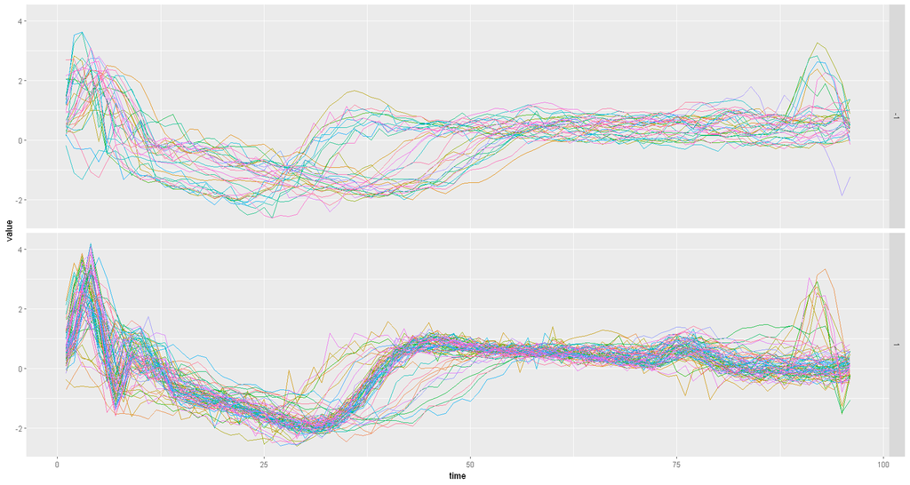

```r
# visualize time series based on class
ggplot(train_data_long, aes(time, value)) + geom_line(aes(color = as.character(id)), show.legend = FALSE) +
     facet_grid(class~.)
```

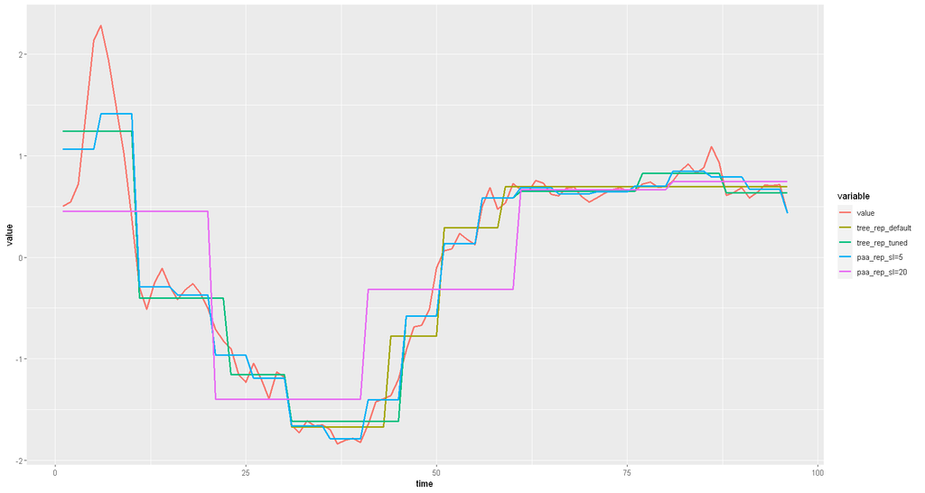

```r
representation(data=train_data, long_data=train_data_long, last_series_id = 1, plot_represenations = TRUE)
```

```r
# calculate representations for whole dataset
reps = representation(data=train_data, long_data=train_data_long, last_series_id = nrow(train_data), plot_represenations = FALSE)
fwrite(reps, sprintf('hw3_reps_%s_%s.csv', type, dataset), col.names=TRUE)
```

```r
# Create a overall accuracy table to find performance of representations and select the best setting among each representations
reps = fread(sprintf('hw3_reps_%s_%s.csv', type, dataset))
mse = melt(reps, id.vars=c("id", "class", "time"), measure.vars=c("value","tree_rep_default","tree_rep_tuned","paa_rep_sl=5", "paa_rep_sl=20"))
mse[,class:=as.character(class)]
mse = merge(mse, train_data_long[,list(id, class, time, obs=value)], by=c("id",  "class", "time"))
mse[!(variable=="value"), list(mse=mean((value-obs)^2)),list(variable)]
```

| variable | mse |
| --- | --- |
| tree_rep_default | 0.16868359 |
| tree_rep_tuned | 0.11967062 |
| paa_rep_sl=5 | 0.09699356 |
| paa_rep_sl=20 | 0.45026265 |

###### Between tree representations tree_rep_tuned, between paa representation sl=5 will be selected

```r
# change selected raw_series and selected representations to long format and store it in a list
raw_series = dcast(reps[,c(1,2,3,4)], id ~ time, value.var = "value")
tree_rep_tuned = dcast(reps[,c(1,2,3,6)], id ~ time, value.var = "tree_rep_tuned")
paa_rep_sl_5 = dcast(reps[,c(1,2,3,7)], id ~ time, value.var = "paa_rep_sl=5")
train_representation_list = list(raw_series, tree_rep_tuned, paa_rep_sl_5)
```

```r
distance(dataset = dataset, reps = train_representation_list, rep_names = c("raw", "tree_rep_tuned", "paa_rep_sl=5"), dist_names = c("euc", "dtw", "lcss", "erp"),  type = type)
```

[output not shown]

```r
dist_files = list.files(pattern = paste0("hw3_TRAIN_", dataset))
dist_files
```

1. 'hw3_TRAIN_ECG200_dtw_paa_rep_sl=5_dist.csv'

2. 'hw3_TRAIN_ECG200_dtw_raw_dist.csv'

3. 'hw3_TRAIN_ECG200_dtw_tree_rep_tuned_dist.csv'

4. 'hw3_TRAIN_ECG200_erp_paa_rep_sl=5_dist.csv'

5. 'hw3_TRAIN_ECG200_erp_raw_dist.csv'

6. 'hw3_TRAIN_ECG200_erp_tree_rep_tuned_dist.csv'

7. 'hw3_TRAIN_ECG200_euc_paa_rep_sl=5_dist.csv'

8. 'hw3_TRAIN_ECG200_euc_raw_dist.csv'

9. 'hw3_TRAIN_ECG200_euc_tree_rep_tuned_dist.csv'

10. 'hw3_TRAIN_ECG200_lcss_paa_rep_sl=5_dist.csv'

11. 'hw3_TRAIN_ECG200_lcss_raw_dist.csv'

12. 'hw3_TRAIN_ECG200_lcss_tree_rep_tuned_dist.csv'

```r
require(TunePareto)

k_levels = c(1, 3, 5)
set.seed(2021)
# 5 repeats of stratified 10-fold cross-validation
nof_rep = 5
n_fold = 10

result = vector('list',length(dist_files)*nof_rep*n_fold*length(k_levels))

# create test indices to be used in cross-validation
train_classes = train_data$class
cv_indices = generateCVRuns(train_classes, ntimes = nof_rep, nfold = n_fold, leaveOneOut = FALSE, stratified = TRUE)

iter=1
# loop to calculate best k value for nearest neighbour with 10-fold-cross-validation, returns accuracy of each run in each fold
for(m in 1:length(dist_files)){
    dist_mat = as.matrix(fread(dist_files[m], header=FALSE))

    for(i in 1:nof_rep){
        this_fold = cv_indices[[i]]

        for(j in 1:n_fold){
            test_indices = this_fold[[j]]

            for(k in 1:length(k_levels)){
                current_k = k_levels[k]
                current_fold = nn_classify(dist_mat, train_classes, test_indices, k = current_k)
                accuracy = sum(train_classes[test_indices]==current_fold$prediction$predicted)/length(test_indices)
                distance_representation_name =  gsub("hw3_TRAIN_ECG200_", "", dist_files[m])
                tmp = data.table(representation = gsub("hw3_TRAIN_ECG200_", "", dist_files[m]), distance_measure = gsub("hw3_TRAIN_ECG200_", "", dist_files[m]), repid = i, foldid = j, k = current_k, acc = accuracy)
                result[[iter]] = tmp
                iter=iter+1

            }

        }

    }

}

overall_results = rbindlist(result)
summary = overall_results[,list(avg_accuracy = mean(acc), sdev_accuracy=sd(acc)), by=list(distance_measure, k)]
summary[order(-avg_accuracy)]
```

| distance_measure | k | avg_accuracy | sdev_accuracy |
| --- | --- | --- | --- |
| lcss_raw_dist.csv | 3 | 0.698 | 0.13169228 |
| dtw_tree_rep_tuned_dist.csv | 5 | 0.692 | 0.07515969 |
| lcss_raw_dist.csv | 5 | 0.692 | 0.09222864 |
| dtw_raw_dist.csv | 5 | 0.672 | 0.09697464 |
| lcss_paa_rep_sl=5_dist.csv | 5 | 0.654 | 0.11466010 |
| dtw_tree_rep_tuned_dist.csv | 3 | 0.652 | 0.07886956 |
| erp_tree_rep_tuned_dist.csv | 3 | 0.642 | 0.10515295 |
| euc_paa_rep_sl=5_dist.csv | 5 | 0.642 | 0.10896545 |
| lcss_paa_rep_sl=5_dist.csv | 3 | 0.634 | 0.13940105 |
| dtw_paa_rep_sl=5_dist.csv | 5 | 0.632 | 0.09570362 |
| euc_tree_rep_tuned_dist.csv | 3 | 0.622 | 0.12001701 |
| euc_raw_dist.csv | 5 | 0.620 | 0.11065667 |
| euc_paa_rep_sl=5_dist.csv | 3 | 0.616 | 0.14193991 |
| erp_tree_rep_tuned_dist.csv | 5 | 0.612 | 0.11890658 |
| erp_raw_dist.csv | 5 | 0.610 | 0.12163847 |
| dtw_raw_dist.csv | 3 | 0.604 | 0.11421426 |
| euc_raw_dist.csv | 3 | 0.598 | 0.13013337 |
| euc_tree_rep_tuned_dist.csv | 5 | 0.596 | 0.11058287 |
| erp_paa_rep_sl=5_dist.csv | 5 | 0.594 | 0.12022089 |
| erp_raw_dist.csv | 3 | 0.592 | 0.16268161 |
| dtw_paa_rep_sl=5_dist.csv | 3 | 0.584 | 0.10372648 |
| erp_paa_rep_sl=5_dist.csv | 3 | 0.574 | 0.11919800 |
| lcss_tree_rep_tuned_dist.csv | 5 | 0.564 | 0.12577920 |
| lcss_tree_rep_tuned_dist.csv | 3 | 0.562 | 0.12759950 |
| euc_tree_rep_tuned_dist.csv | 1 | 0.014 | 0.03505098 |
| erp_raw_dist.csv | 1 | 0.012 | 0.03854496 |
| erp_tree_rep_tuned_dist.csv | 1 | 0.010 | 0.03030458 |
| lcss_paa_rep_sl=5_dist.csv | 1 | 0.010 | 0.03642157 |
| dtw_raw_dist.csv | 1 | 0.008 | 0.02740475 |
| dtw_tree_rep_tuned_dist.csv | 1 | 0.008 | 0.03404679 |
| lcss_raw_dist.csv | 1 | 0.008 | 0.04444671 |
| euc_raw_dist.csv | 1 | 0.006 | 0.02398979 |
| euc_paa_rep_sl=5_dist.csv | 1 | 0.004 | 0.01979487 |
| dtw_paa_rep_sl=5_dist.csv | 1 | 0.002 | 0.01414214 |
| erp_paa_rep_sl=5_dist.csv | 1 | 0.002 | 0.01414214 |
| lcss_tree_rep_tuned_dist.csv | 1 | 0.002 | 0.01414214 |

###### So, the summary table implies that for the ECG200 series following setting is the best for training set

- Distance measure: LCSS
- Representation: Raw
- k=3

```r
overall_summary_table = data.table(dataset=dataset, type=type, distance_measure = "LCSS", representation = "Raw", k="3", accuracy = summary[order(-avg_accuracy)][1,3])
bests_for_each_train_dataset = fread("hw3_bests_for_each_train_dataset.csv", header=TRUE)
bests_for_each_train_dataset = rbind(bests_for_each_train_dataset, overall_summary_table)
fwrite(bests_for_each_train_dataset, "hw3_bests_for_each_train_dataset.csv")
```

#### ECG200 (Test)

```r
type = "TEST"
test_data = preprocess(dataset=dataset, type=type, file_format=file_format, to_long=FALSE)
test_data_long = preprocess(dataset=dataset, type=type, file_format=file_format, to_long=TRUE)
test_classes = test_data$class

# calculate representations for whole dataset
reps = representation(data=test_data, long_data=test_data_long, last_series_id = nrow(test_data), plot_represenations = FALSE)
fwrite(reps, sprintf('hw3_reps_%s_%s.csv', type, dataset), col.names=TRUE)
reps = fread(sprintf('hw3_reps_%s_%s.csv', type, dataset))

# since raw series performed the best in train set, only use this representation
raw_series = dcast(reps[,c(1,2,3,4)], id ~ time, value.var = "value")
test_representation_list = list(raw_series)

# since lcss distance performed the best in train set, only use this distance measure
distance(dataset = dataset, reps = test_representation_list, rep_names = c("raw"), dist_names = c("lcss"), type = type)

best_k_levels = 3
dist_files = list.files(pattern = paste0("hw3_TEST_", dataset))

print(dist_files[1])
dist_mat = as.matrix(fread(dist_files[1], header=FALSE))

best_k_level_for_current_approach = best_k_levels
ordered_neighbours = apply(dist_mat, 1, order)
nearest_class = apply(ordered_neighbours[1:best_k_level_for_current_approach,], 2, function(x) {test_classes[x]})
nearest_class = data.table(id=1:nrow(dist_mat), t(nearest_class))

long_nn_class = melt(nearest_class,'id')
class_counts = long_nn_class[,.N,list(id,value)]
class_counts[,predicted_prob:=N/best_k_level_for_current_approach]
wide_class_prob_predictions = dcast(class_counts, id~value, value.var='predicted_prob')
wide_class_prob_predictions[is.na(wide_class_prob_predictions)]=0
class_predictions = class_counts[,list(predicted = value[which.max(N)]), by=list(id)]

# create confusion matrix and report accuracy
true_status = test_classes
confusion_matrix = table(true_status, prediction=class_predictions$predicted)
print(confusion_matrix)

accuracy = sum(true_status==class_predictions$predicted)/length(class_predictions$predicted)
print(accuracy)
```

```
x being coerced from class: matrix to data.table
```

```
[1] "hw3_TEST_ECG200_lcss_raw_dist.csv"
           prediction
true_status -1  1
         -1 26 10
         1  44 20
[1] 0.46
```

```r
overall_summary_table = data.table(dataset=dataset, type=type, distance_measure = "LCSS", representation = "Raw", k="3", accuracy = accuracy)
bests_for_each_test_dataset = fread("hw3_bests_for_each_test_dataset.csv", header=TRUE)
bests_for_each_test_dataset = rbind(bests_for_each_test_dataset, overall_summary_table)
fwrite(bests_for_each_test_dataset, "hw3_bests_for_each_test_dataset.csv")
```

#### Dataset 4: Plane (Train)

```r
dataset = "Plane"
type = "TRAIN"
file_format = "txt"
```

```r
train_data = preprocess(dataset=dataset, type=type, file_format=file_format, to_long=FALSE)
train_data_long = preprocess(dataset=dataset, type=type, file_format=file_format, to_long=TRUE)
```

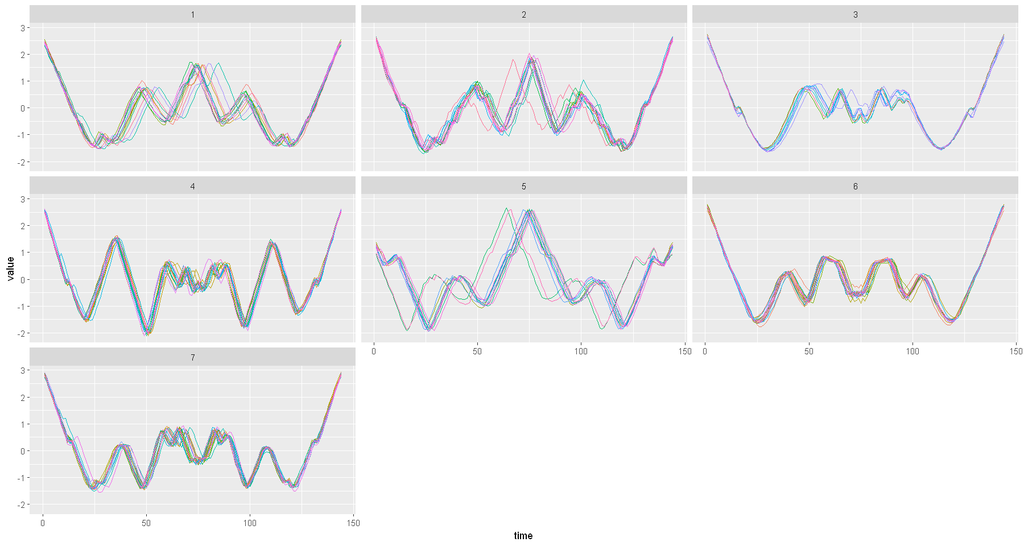

```r
# visualize time series based on class
ggplot(train_data_long, aes(time, value)) + geom_line(aes(color = as.character(id)), show.legend = FALSE) +
     facet_wrap(class~.)
```

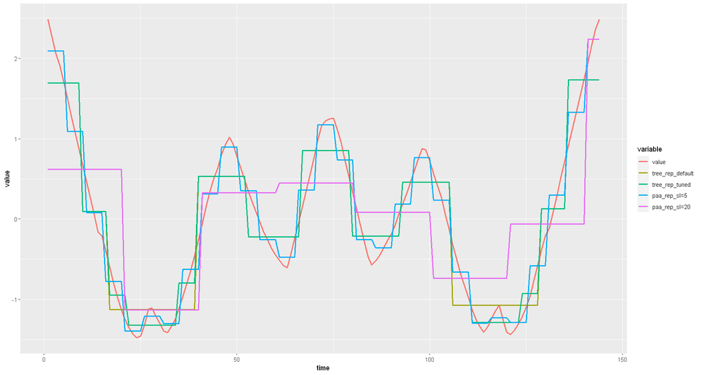

```r
representation(data=train_data, long_data=train_data_long, last_series_id = 1, plot_represenations = TRUE)
```

```r
# calculate representations for whole dataset
reps = representation(data=train_data, long_data=train_data_long, last_series_id = nrow(train_data), plot_represenations = FALSE)
fwrite(reps, sprintf('hw3_reps_%s_%s.csv', type, dataset), col.names=TRUE)
```

```r
# Create a overall accuracy table to find performance of representations and select the best setting among each representations
reps = fread(sprintf('hw3_reps_%s_%s.csv', type, dataset))
mse = melt(reps, id.vars=c("id", "class", "time"), measure.vars=c("value","tree_rep_default","tree_rep_tuned","paa_rep_sl=5", "paa_rep_sl=20"))
mse[,class:=as.character(class)]
mse = merge(mse, train_data_long[,list(id, class, time, obs=value)], by=c("id",  "class", "time"))
mse[!(variable=="value"), list(mse=mean((value-obs)^2)),list(variable)]
```

| variable | mse |
| --- | --- |
| tree_rep_default | 0.15150276 |
| tree_rep_tuned | 0.10968078 |
| paa_rep_sl=5 | 0.05270329 |
| paa_rep_sl=20 | 0.51952650 |

###### Between tree representations tree_rep_tuned, between paa representation sl=5 will be selected

```r
# change selected raw_series and selected representations to long format and store it in a list
raw_series = dcast(reps[,c(1,2,3,4)], id ~ time, value.var = "value")
tree_rep_tuned = dcast(reps[,c(1,2,3,6)], id ~ time, value.var = "tree_rep_tuned")
paa_rep_sl_5 = dcast(reps[,c(1,2,3,7)], id ~ time, value.var = "paa_rep_sl=5")
train_representation_list = list(raw_series, tree_rep_tuned, paa_rep_sl_5)
```

```r
distance(dataset = dataset, reps = train_representation_list, rep_names = c("raw", "tree_rep_tuned", "paa_rep_sl=5"), dist_names = c("euc", "dtw", "lcss", "erp"),  type = type)
```

[output not shown]

```r
dist_files = list.files(pattern = paste0("hw3_TRAIN_", dataset))
dist_files
```

1. 'hw3_TRAIN_Plane_dtw_paa_rep_sl=5_dist.csv'

2. 'hw3_TRAIN_Plane_dtw_raw_dist.csv'

3. 'hw3_TRAIN_Plane_dtw_tree_rep_tuned_dist.csv'

4. 'hw3_TRAIN_Plane_erp_paa_rep_sl=5_dist.csv'

5. 'hw3_TRAIN_Plane_erp_raw_dist.csv'

6. 'hw3_TRAIN_Plane_erp_tree_rep_tuned_dist.csv'

7. 'hw3_TRAIN_Plane_euc_paa_rep_sl=5_dist.csv'

8. 'hw3_TRAIN_Plane_euc_raw_dist.csv'

9. 'hw3_TRAIN_Plane_euc_tree_rep_tuned_dist.csv'

10. 'hw3_TRAIN_Plane_lcss_paa_rep_sl=5_dist.csv'

11. 'hw3_TRAIN_Plane_lcss_raw_dist.csv'

12. 'hw3_TRAIN_Plane_lcss_tree_rep_tuned_dist.csv'

```r
require(TunePareto)

k_levels = c(1, 3, 5)
set.seed(2021)
# 5 repeats of stratified 10-fold cross-validation
nof_rep = 5
n_fold = 10

result = vector('list',length(dist_files)*nof_rep*n_fold*length(k_levels))

# create test indices to be used in cross-validation
train_classes = train_data$class
cv_indices = generateCVRuns(train_classes, ntimes = nof_rep, nfold = n_fold, leaveOneOut = FALSE, stratified = TRUE)

iter=1
# loop to calculate best k value for nearest neighbour with 10-fold-cross-validation, returns accuracy of each run in each fold
for(m in 1:length(dist_files)){
    dist_mat = as.matrix(fread(dist_files[m], header=FALSE))

    for(i in 1:nof_rep){
        this_fold = cv_indices[[i]]

        for(j in 1:n_fold){
            test_indices = this_fold[[j]]

            for(k in 1:length(k_levels)){
                current_k = k_levels[k]
                current_fold = nn_classify(dist_mat, train_classes, test_indices, k = current_k)
                accuracy = sum(train_classes[test_indices]==current_fold$prediction$predicted)/length(test_indices)
                distance_representation_name =  gsub("hw3_TRAIN_Plane_", "", dist_files[m])
                tmp = data.table(representation = gsub("hw3_TRAIN_Plane_", "", dist_files[m]), distance_measure = gsub("hw3_TRAIN_Plane_", "", dist_files[m]), repid = i, foldid = j, k = current_k, acc = accuracy)
                result[[iter]] = tmp
                iter=iter+1

            }

        }

    }

}

overall_results = rbindlist(result)
summary = overall_results[,list(avg_accuracy = mean(acc), sdev_accuracy=sd(acc)), by=list(distance_measure, k)]
summary[order(-avg_accuracy)]
```

| distance_measure | k | avg_accuracy | sdev_accuracy |
| --- | --- | --- | --- |
| lcss_raw_dist.csv | 5 | 0.264727273 | 0.12033349 |
| lcss_raw_dist.csv | 3 | 0.217636364 | 0.10093859 |
| lcss_tree_rep_tuned_dist.csv | 3 | 0.176727273 | 0.12639720 |
| lcss_tree_rep_tuned_dist.csv | 5 | 0.171636364 | 0.10062446 |
| lcss_paa_rep_sl=5_dist.csv | 5 | 0.158727273 | 0.09887562 |
| dtw_tree_rep_tuned_dist.csv | 3 | 0.125272727 | 0.09054268 |
| dtw_tree_rep_tuned_dist.csv | 5 | 0.118727273 | 0.08132007 |
| erp_paa_rep_sl=5_dist.csv | 5 | 0.114363636 | 0.10032987 |
| euc_paa_rep_sl=5_dist.csv | 5 | 0.112545455 | 0.07863076 |
| dtw_raw_dist.csv | 5 | 0.110363636 | 0.08112487 |
| lcss_paa_rep_sl=5_dist.csv | 3 | 0.109818182 | 0.07901485 |
| erp_tree_rep_tuned_dist.csv | 3 | 0.098545455 | 0.08455254 |
| erp_tree_rep_tuned_dist.csv | 5 | 0.096909091 | 0.07436945 |
| euc_raw_dist.csv | 5 | 0.094727273 | 0.07597325 |
| dtw_paa_rep_sl=5_dist.csv | 5 | 0.092909091 | 0.07312715 |
| euc_tree_rep_tuned_dist.csv | 5 | 0.090545455 | 0.07867515 |
| euc_paa_rep_sl=5_dist.csv | 3 | 0.087454545 | 0.07863076 |
| erp_raw_dist.csv | 3 | 0.080909091 | 0.07275626 |
| dtw_raw_dist.csv | 3 | 0.076363636 | 0.06803013 |
| euc_tree_rep_tuned_dist.csv | 3 | 0.075454545 | 0.07059131 |
| erp_raw_dist.csv | 5 | 0.069636364 | 0.06777205 |
| erp_paa_rep_sl=5_dist.csv | 3 | 0.068545455 | 0.06921505 |
| euc_raw_dist.csv | 3 | 0.066000000 | 0.06847026 |
| dtw_paa_rep_sl=5_dist.csv | 3 | 0.055454545 | 0.06144518 |
| lcss_raw_dist.csv | 1 | 0.017090909 | 0.04590280 |
| erp_raw_dist.csv | 1 | 0.016727273 | 0.04050449 |
| lcss_paa_rep_sl=5_dist.csv | 1 | 0.013636364 | 0.03417584 |
| dtw_paa_rep_sl=5_dist.csv | 1 | 0.013090909 | 0.03281168 |
| euc_paa_rep_sl=5_dist.csv | 1 | 0.011636364 | 0.03186665 |
| erp_paa_rep_sl=5_dist.csv | 1 | 0.011090909 | 0.03036240 |
| euc_raw_dist.csv | 1 | 0.009454545 | 0.02868690 |
| dtw_raw_dist.csv | 1 | 0.007636364 | 0.02619130 |
| euc_tree_rep_tuned_dist.csv | 1 | 0.007636364 | 0.02619130 |
| lcss_tree_rep_tuned_dist.csv | 1 | 0.003818182 | 0.01891740 |
| erp_tree_rep_tuned_dist.csv | 1 | 0.003636364 | 0.01799533 |
| dtw_tree_rep_tuned_dist.csv | 1 | 0.002000000 | 0.01414214 |

###### So, the summary table implies that for the Plane series following setting is the best for training set

- Distance measure: LCSS
- Representation: Raw
- k=5

```r
overall_summary_table = data.table(dataset=dataset, type=type, distance_measure = "LCSS", representation = "Raw", k="5", accuracy = summary[order(-avg_accuracy)][1,3])
bests_for_each_train_dataset = fread("hw3_bests_for_each_train_dataset.csv", header=TRUE)
bests_for_each_train_dataset = rbind(bests_for_each_train_dataset, overall_summary_table)
fwrite(bests_for_each_train_dataset, "hw3_bests_for_each_train_dataset.csv")
```

#### Plane (Test)

```r
type = "TEST"
test_data = preprocess(dataset=dataset, type=type, file_format=file_format, to_long=FALSE)
test_data_long = preprocess(dataset=dataset, type=type, file_format=file_format, to_long=TRUE)
test_classes = test_data$class

# calculate representations for whole dataset
reps = representation(data=test_data, long_data=test_data_long, last_series_id = nrow(test_data), plot_represenations = FALSE)
fwrite(reps, sprintf('hw3_reps_%s_%s.csv', type, dataset), col.names=TRUE)
reps = fread(sprintf('hw3_reps_%s_%s.csv', type, dataset))

# since raw series performed the best in train set, only use this representation
raw_series = dcast(reps[,c(1,2,3,4)], id ~ time, value.var = "value")
test_representation_list = list(raw_series)

# since lcss distance performed the best in train set, only use this distance measure
distance(dataset = dataset, reps = test_representation_list, rep_names = c("raw"), dist_names = c("lcss"), type = type)

best_k_levels = 5
dist_files = list.files(pattern = paste0("hw3_TEST_", dataset))

print(dist_files[1])
dist_mat = as.matrix(fread(dist_files[1], header=FALSE))

best_k_level_for_current_approach = best_k_levels
ordered_neighbours = apply(dist_mat, 1, order)
nearest_class = apply(ordered_neighbours[1:best_k_level_for_current_approach,], 2, function(x) {test_classes[x]})
nearest_class = data.table(id=1:nrow(dist_mat), t(nearest_class))

long_nn_class = melt(nearest_class,'id')
class_counts = long_nn_class[,.N,list(id,value)]
class_counts[,predicted_prob:=N/best_k_level_for_current_approach]
wide_class_prob_predictions = dcast(class_counts, id~value, value.var='predicted_prob')
wide_class_prob_predictions[is.na(wide_class_prob_predictions)]=0
class_predictions = class_counts[,list(predicted = value[which.max(N)]), by=list(id)]

# create confusion matrix and report accuracy
true_status = test_classes
confusion_matrix = table(true_status, prediction=class_predictions$predicted)
print(confusion_matrix)

accuracy = sum(true_status==class_predictions$predicted)/length(class_predictions$predicted)
print(accuracy)
```

```
x being coerced from class: matrix to data.table
```

```
[1] "hw3_TEST_Plane_lcss_raw_dist.csv"
           prediction
true_status 1 2 3 4 5 6 7
          1 2 5 0 4 2 0 2
          2 1 2 4 5 0 1 3
          3 2 9 1 6 1 1 1
          4 4 2 4 4 0 0 0
          5 1 5 0 7 3 0 1
          6 2 3 2 4 0 0 1
          7 2 3 1 2 0 0 2
[1] 0.1333333
```

```r
overall_summary_table = data.table(dataset=dataset, type=type, distance_measure = "LCSS", representation = "Raw", k="5", accuracy = accuracy)
bests_for_each_test_dataset = fread("hw3_bests_for_each_test_dataset.csv", header=TRUE)
bests_for_each_test_dataset = rbind(bests_for_each_test_dataset, overall_summary_table)
fwrite(bests_for_each_test_dataset, "hw3_bests_for_each_test_dataset.csv")
```

#### Dataset 5: SyntheticControl (Train)

```r
dataset = "SyntheticControl"
type = "TRAIN"
file_format = "txt"
```

```r
train_data = preprocess(dataset=dataset, type=type, file_format=file_format, to_long=FALSE)
train_data_long = preprocess(dataset=dataset, type=type, file_format=file_format, to_long=TRUE)
```

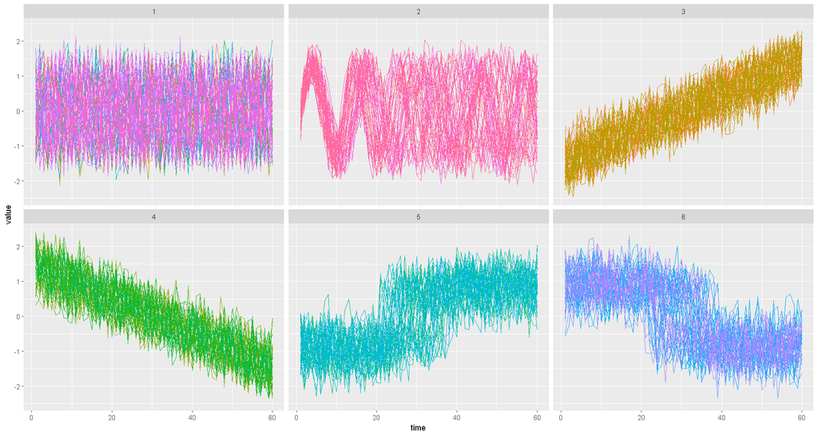

```r
# visualize time series based on class
ggplot(train_data_long, aes(time, value)) + geom_line(aes(color = as.character(id)), show.legend = FALSE) +
     facet_wrap(class~.)
```

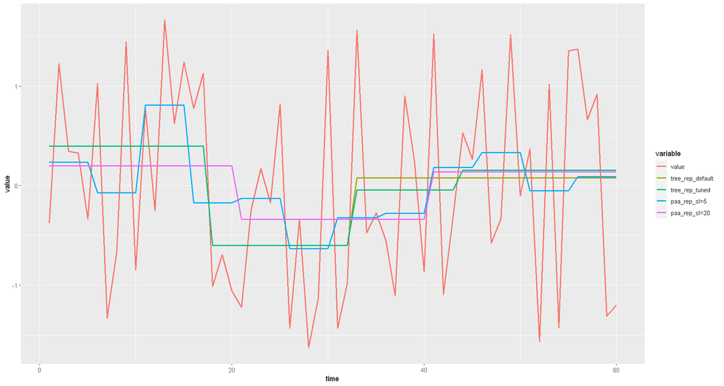

```r
representation(data=train_data, long_data=train_data_long, last_series_id = 1, plot_represenations = TRUE)
```

```r
# calculate representations for whole dataset
reps = representation(data=train_data, long_data=train_data_long, last_series_id = nrow(train_data), plot_represenations = FALSE)
fwrite(reps, sprintf('hw3_reps_%s_%s.csv', type, dataset), col.names=TRUE)
```

```r
# Create a overall accuracy table to find performance of representations and select the best setting among each representations
reps = fread(sprintf('hw3_reps_%s_%s.csv', type, dataset))
reps[,value:=as.numeric(value)]
mse = melt(reps, id.vars=c("id", "class", "time"), measure.vars=c("value","tree_rep_default","tree_rep_tuned","paa_rep_sl=5", "paa_rep_sl=20"))
mse[,class:=as.character(class)]
mse = merge(mse, train_data_long[,list(id, class, time, obs=value)], by=c("id",  "class", "time"))
mse[!(variable=="value"), list(mse=mean((value-obs)^2)),list(variable)]
```

| variable | mse |
| --- | --- |
| tree_rep_default | 0.3896597 |
| tree_rep_tuned | 0.3302756 |
| paa_rep_sl=5 | 0.3694996 |
| paa_rep_sl=20 | 0.5587250 |

###### Between tree representations tree_rep_tuned, between paa representation sl=5 will be selected

```r
# change selected raw_series and selected representations to long format and store it in a list
raw_series = dcast(reps[,c(1,2,3,4)], id ~ time, value.var = "value")
tree_rep_tuned = dcast(reps[,c(1,2,3,6)], id ~ time, value.var = "tree_rep_tuned")
paa_rep_sl_5 = dcast(reps[,c(1,2,3,7)], id ~ time, value.var = "paa_rep_sl=5")
train_representation_list = list(raw_series, tree_rep_tuned, paa_rep_sl_5)
```

```r
distance(dataset = dataset, reps = train_representation_list, rep_names = c("raw", "tree_rep_tuned", "paa_rep_sl=5"), dist_names = c("euc", "dtw", "lcss", "erp"),  type = type)
```

[output not shown]

```r
dist_files = list.files(pattern = paste0("hw3_TRAIN_", dataset))
dist_files
```

1. 'hw3_TRAIN_SyntheticControl_dtw_paa_rep_sl=5_dist.csv'

2. 'hw3_TRAIN_SyntheticControl_dtw_raw_dist.csv'

3. 'hw3_TRAIN_SyntheticControl_dtw_tree_rep_tuned_dist.csv'

4. 'hw3_TRAIN_SyntheticControl_erp_paa_rep_sl=5_dist.csv'

5. 'hw3_TRAIN_SyntheticControl_erp_raw_dist.csv'

6. 'hw3_TRAIN_SyntheticControl_erp_tree_rep_tuned_dist.csv'

7. 'hw3_TRAIN_SyntheticControl_euc_paa_rep_sl=5_dist.csv'

8. 'hw3_TRAIN_SyntheticControl_euc_raw_dist.csv'

9. 'hw3_TRAIN_SyntheticControl_euc_tree_rep_tuned_dist.csv'

10. 'hw3_TRAIN_SyntheticControl_lcss_paa_rep_sl=5_dist.csv'

11. 'hw3_TRAIN_SyntheticControl_lcss_raw_dist.csv'

12. 'hw3_TRAIN_SyntheticControl_lcss_tree_rep_tuned_dist.csv'

```r
require(TunePareto)

k_levels = c(1, 3, 5)
set.seed(2021)
# 5 repeats of stratified 10-fold cross-validation
nof_rep = 5
n_fold = 10

result = vector('list',length(dist_files)*nof_rep*n_fold*length(k_levels))

# create test indices to be used in cross-validation
train_classes = train_data$class
cv_indices = generateCVRuns(train_classes, ntimes = nof_rep, nfold = n_fold, leaveOneOut = FALSE, stratified = TRUE)

iter=1
# loop to calculate best k value for nearest neighbour with 10-fold-cross-validation, returns accuracy of each run in each fold
for(m in 1:length(dist_files)){
    dist_mat = as.matrix(fread(dist_files[m], header=FALSE))

    for(i in 1:nof_rep){
        this_fold = cv_indices[[i]]

        for(j in 1:n_fold){
            test_indices = this_fold[[j]]

            for(k in 1:length(k_levels)){
                current_k = k_levels[k]
                current_fold = nn_classify(dist_mat, train_classes, test_indices, k = current_k)
                accuracy = sum(train_classes[test_indices]==current_fold$prediction$predicted)/length(test_indices)
                distance_representation_name =  gsub("hw3_TRAIN_SyntheticControl_", "", dist_files[m])
                tmp = data.table(representation = gsub("hw3_TRAIN_SyntheticControl_", "", dist_files[m]), distance_measure = gsub("hw3_TRAIN_SyntheticControl_", "", dist_files[m]), repid = i, foldid = j, k = current_k, acc = accuracy)
                result[[iter]] = tmp
                iter=iter+1

            }

        }

    }

}

overall_results = rbindlist(result)
summary = overall_results[,list(avg_accuracy = mean(acc), sdev_accuracy=sd(acc)), by=list(distance_measure, k)]
summary[order(-avg_accuracy)]
```

| distance_measure | k | avg_accuracy | sdev_accuracy |
| --- | --- | --- | --- |
| euc_paa_rep_sl=5_dist.csv | 3 | 0.9980000000 | 0.007996598 |
| euc_paa_rep_sl=5_dist.csv | 5 | 0.9933333333 | 0.019047619 |
| euc_tree_rep_tuned_dist.csv | 3 | 0.9926666667 | 0.013948399 |
| erp_paa_rep_sl=5_dist.csv | 3 | 0.9920000000 | 0.015879364 |
| erp_tree_rep_tuned_dist.csv | 5 | 0.9893333333 | 0.015707069 |
| erp_tree_rep_tuned_dist.csv | 3 | 0.9886666667 | 0.015950604 |
| dtw_paa_rep_sl=5_dist.csv | 5 | 0.9886666667 | 0.017313961 |
| euc_tree_rep_tuned_dist.csv | 5 | 0.9873333333 | 0.017676868 |
| erp_paa_rep_sl=5_dist.csv | 5 | 0.9873333333 | 0.018916213 |
| dtw_tree_rep_tuned_dist.csv | 5 | 0.9860000000 | 0.020303815 |
| erp_raw_dist.csv | 5 | 0.9840000000 | 0.026289855 |
| erp_raw_dist.csv | 3 | 0.9826666667 | 0.021549921 |
| dtw_tree_rep_tuned_dist.csv | 3 | 0.9813333333 | 0.022497165 |
| dtw_paa_rep_sl=5_dist.csv | 3 | 0.9786666667 | 0.021038783 |
| dtw_raw_dist.csv | 5 | 0.9766666667 | 0.028769157 |
| dtw_raw_dist.csv | 3 | 0.9746666667 | 0.030535656 |
| euc_raw_dist.csv | 3 | 0.8880000000 | 0.045054766 |
| euc_raw_dist.csv | 5 | 0.8773333333 | 0.044385448 |
| lcss_tree_rep_tuned_dist.csv | 3 | 0.1593333333 | 0.015489006 |
| lcss_tree_rep_tuned_dist.csv | 5 | 0.1520000000 | 0.021465577 |
| lcss_paa_rep_sl=5_dist.csv | 3 | 0.0653333333 | 0.040941305 |
| lcss_paa_rep_sl=5_dist.csv | 5 | 0.0293333333 | 0.032743073 |
| lcss_raw_dist.csv | 3 | 0.0186666667 | 0.022497165 |
| lcss_tree_rep_tuned_dist.csv | 1 | 0.0173333333 | 0.032464877 |
| lcss_raw_dist.csv | 5 | 0.0106666667 | 0.018368859 |
| dtw_raw_dist.csv | 1 | 0.0066666667 | 0.013468701 |
| erp_tree_rep_tuned_dist.csv | 1 | 0.0066666667 | 0.016495722 |
| dtw_tree_rep_tuned_dist.csv | 1 | 0.0060000000 | 0.014584184 |
| euc_tree_rep_tuned_dist.csv | 1 | 0.0053333333 | 0.012344268 |
| erp_paa_rep_sl=5_dist.csv | 1 | 0.0040000000 | 0.010942024 |
| dtw_paa_rep_sl=5_dist.csv | 1 | 0.0033333333 | 0.010101525 |
| euc_paa_rep_sl=5_dist.csv | 1 | 0.0033333333 | 0.010101525 |
| euc_raw_dist.csv | 1 | 0.0026666667 | 0.009134917 |
| erp_raw_dist.csv | 1 | 0.0020000000 | 0.007996598 |
| lcss_raw_dist.csv | 1 | 0.0020000000 | 0.010454523 |
| lcss_paa_rep_sl=5_dist.csv | 1 | 0.0006666667 | 0.004714045 |

###### So, the summary table implies that for the SyntheticControl series following setting is the best for training set

- Distance measure: EUC
- Representation: PAA
- k=3

```r
overall_summary_table = data.table(dataset=dataset, type=type, distance_measure = "EUC", representation = "PAA", k="3", accuracy = summary[order(-avg_accuracy)][1,3])
bests_for_each_train_dataset = fread("hw3_bests_for_each_train_dataset.csv", header=TRUE)
bests_for_each_train_dataset = rbind(bests_for_each_train_dataset, overall_summary_table)
fwrite(bests_for_each_train_dataset, "hw3_bests_for_each_train_dataset.csv")
```

#### SyntheticControl (Test)

```r
type = "TEST"
test_data = preprocess(dataset=dataset, type=type, file_format=file_format, to_long=FALSE)
test_data_long = preprocess(dataset=dataset, type=type, file_format=file_format, to_long=TRUE)
test_classes = test_data$class

# calculate representations for whole dataset
reps = representation(data=test_data, long_data=test_data_long, last_series_id = nrow(test_data), plot_represenations = FALSE)
fwrite(reps, sprintf('hw3_reps_%s_%s.csv', type, dataset), col.names=TRUE)
reps = fread(sprintf('hw3_reps_%s_%s.csv', type, dataset))

# since paa performed the best in train set, only use this representation
paa_rep_sl_5 = dcast(reps[,c(1,2,3,7)], id ~ time, value.var = "paa_rep_sl=5")
test_representation_list = list(paa_rep_sl_5)

# since euc distance performed the best in train set, only use this distance measure
distance(dataset = dataset, reps = test_representation_list, rep_names = c("paa"), dist_names = c("euc"), type = type)

best_k_levels = 3
dist_files = list.files(pattern = paste0("hw3_TEST_", dataset))

print(dist_files[1])
dist_mat = as.matrix(fread(dist_files[1], header=FALSE))

best_k_level_for_current_approach = best_k_levels
ordered_neighbours = apply(dist_mat, 1, order)
nearest_class = apply(ordered_neighbours[1:best_k_level_for_current_approach,], 2, function(x) {test_classes[x]})
nearest_class = data.table(id=1:nrow(dist_mat), t(nearest_class))

long_nn_class = melt(nearest_class,'id')
class_counts = long_nn_class[,.N,list(id,value)]
class_counts[,predicted_prob:=N/best_k_level_for_current_approach]
wide_class_prob_predictions = dcast(class_counts, id~value, value.var='predicted_prob')
wide_class_prob_predictions[is.na(wide_class_prob_predictions)]=0
class_predictions = class_counts[,list(predicted = value[which.max(N)]), by=list(id)]

# create confusion matrix and report accuracy
true_status = test_classes
confusion_matrix = table(true_status, prediction=class_predictions$predicted)
print(confusion_matrix)

accuracy = sum(true_status==class_predictions$predicted)/length(class_predictions$predicted)
print(accuracy)
```

```
x being coerced from class: matrix to data.table
```

```
[1] "hw3_TEST_SyntheticControl_euc_paa_dist.csv"
           prediction
true_status  1  2  3  4  5  6
          1 47  3  0  0  0  0
          2  0 50  0  0  0  0
          3  0  0 50  0  0  0
          4  0  0  0 49  0  1
          5  0  0  0  0 50  0
          6  0  0  0  1  0 49
[1] 0.9833333
```

```r
overall_summary_table = data.table(dataset=dataset, type=type, distance_measure = "EUC", representation = "PAA", k="3", accuracy = accuracy)
bests_for_each_test_dataset = fread("hw3_bests_for_each_test_dataset.csv", header=TRUE)
bests_for_each_test_dataset = rbind(bests_for_each_test_dataset, overall_summary_table)
fwrite(bests_for_each_test_dataset, "hw3_bests_for_each_test_dataset.csv")
```

#### Final Results & Comments

###### First thing first, it is clear that there is no concept that one size fits all in time series classification. Each dataset must be assessed individually. For example, Earthquakes dataset has so many up and downs so it is not easy to represent it with any selected methods. Best perfomend settings for each dataset for both train and test sets can be seen in tables below with their accuracy results. One can see that it is inevitable that perfomance of the algorithms in syntetic data is farmost better than the real data. Also the performance in plane dataset is very low. This may due to the size of the data. Because it has less train data but so many class.

```r
bests_for_each_test_dataset = fread("hw3_bests_for_each_test_dataset.csv", header=TRUE)
bests_for_each_test_dataset
```

| dataset | type | distance_measure | representation | k | accuracy |
| --- | --- | --- | --- | --- | --- |
| PowerCons | TEST | ERP | Raw | 5 | 0.5388889 |
| Earthquakes | TEST | LCSS | Raw | 5 | 0.7553957 |
| ECG200 | TEST | LCSS | Raw | 3 | 0.4600000 |
| Plane | TEST | LCSS | Raw | 5 | 0.1333333 |
| SyntheticControl | TEST | EUC | PAA | 3 | 0.9833333 |

```r
bests_for_each_train_dataset = fread("hw3_bests_for_each_train_dataset.csv", header=TRUE)
bests_for_each_train_dataset
```

| dataset | type | distance_measure | representation | k | accuracy.avg_accuracy |
| --- | --- | --- | --- | --- | --- |
| PowerCons | TRAIN | ERP | Raw | 5 | 0.6277778 |
| Earthquakes | TRAIN | LCSS | Raw | 5 | 0.8198674 |
| ECG200 | TRAIN | LCSS | Raw | 3 | 0.6980000 |
| Plane | TRAIN | LCSS | Raw | 5 | 0.2647273 |
| SyntheticControl | TRAIN | EUC | PAA | 3 | 0.9980000 |